# Biopsy Biomarker Variable Selection

Zehui Bai

Stand: 2021-04-22 18:08 Uhr

# Task description

For 569 patients with benign or malignant breast cancer a biopsy was taken (DataScientist_test_data.csv). Based on that biomarkers (features) were computed.

The objective of this task is to **derive a cutoff of one of the features** and to **find a combination of potentially diagnostic variables** for the identification of benign vs. malignant tumors.

Specifically, complete the following exercises

1. Provide a descriptive overview of the data.
2. Analyze the correlation structure of the biomarkers.
3. Identify potential biomarker candidates related to the cancer diagnosis (benign vs. malignant).
4. Evaluate the performance of the model with the selected biomarkers.
5. Find a cutoff for the mean area separating the patients into benign and malignant breast cancer. In case you are not familiar with cutoff detection, please try to collect ideas how this could be done.

# Data Exploration

First of all, the total display variable structure and type, and whether it is missing. Where Diagnosis is a target variable, the rest is a biomarker, and there is no missing value.

```r
# import dataset
data <- read.csv("~/Library/Mobile Documents/com~apple~CloudDocs/02. Programm/01 R/00 Data/Biopsy.csv")
## Drop the patient ID and blank column
biopsy <- data[-c(1,33)]
str(biopsy)
```

```
## 'data.frame':    569 obs. of  31 variables:
##  $ diagnosis              : chr  "M" "M" "M" "M" ...
##  $ radius_mean            : num  18 20.6 19.7 11.4 20.3 ...
##  $ texture_mean           : num  10.4 17.8 21.2 20.4 14.3 ...
##  $ perimeter_mean         : num  122.8 132.9 130 77.6 135.1 ...
##  $ area_mean              : num  1001 1326 1203 386 1297 ...
##  $ smoothness_mean        : num  0.1184 0.0847 0.1096 0.1425 0.1003 ...
##  $ compactness_mean       : num  0.2776 0.0786 0.1599 0.2839 0.1328 ...
##  $ concavity_mean         : num  0.3001 0.0869 0.1974 0.2414 0.198 ...
##  $ concave.points_mean    : num  0.1471 0.0702 0.1279 0.1052 0.1043 ...
##  $ symmetry_mean          : num  0.242 0.181 0.207 0.26 0.181 ...
##  $ fractal_dimension_mean : num  0.0787 0.0567 0.06 0.0974 0.0588 ...
##  $ radius_se              : num  1.095 0.543 0.746 0.496 0.757 ...
##  $ texture_se             : num  0.905 0.734 0.787 1.156 0.781 ...
##  $ perimeter_se           : num  8.59 3.4 4.58 3.44 5.44 ...
```

[output cut: 17 more lines]

```r
## Explore data: Check the missing ratio of biomaker
sapply(biopsy,function(x)sum(is.na(x)))
```

```
##               diagnosis             radius_mean            texture_mean
##                       0                       0                       0
##          perimeter_mean               area_mean         smoothness_mean
##                       0                       0                       0
##        compactness_mean          concavity_mean     concave.points_mean
##                       0                       0                       0
##           symmetry_mean  fractal_dimension_mean               radius_se
##                       0                       0                       0
##              texture_se            perimeter_se                 area_se
##                       0                       0                       0
##           smoothness_se          compactness_se            concavity_se
##                       0                       0                       0
##       concave.points_se             symmetry_se    fractal_dimension_se
##                       0                       0                       0
##            radius_worst           texture_worst         perimeter_worst
##                       0                       0                       0
##              area_worst        smoothness_worst       compactness_worst
##                       0                       0                       0
##         concavity_worst    concave.points_worst          symmetry_worst
##                       0                       0                       0
## fractal_dimension_worst
##                       0
```

## Explore the variable diagnosis

For variable diagnosis, “B” denotes the benign tumor and “M” denotes the malignant tumor. First check the percent of the two categories of variable diagnosis and visualizate. It is very important to check the ratio of benign and malignant in the response variable diagnosis to ensure that the data is divided and balanced. If a result is too sparse, it may cause problems of mis-classification. After checking the ratio of benign to malignant is more ideal, about 5:3.

```r
biopsy$diagnosis <- factor(biopsy$diagnosis,
                           levels = c("B", "M"),
                           labels = c("Benign", "Malignant"))
table(biopsy$diagnosis)
```

```
##
##    Benign Malignant
##       357       212
```

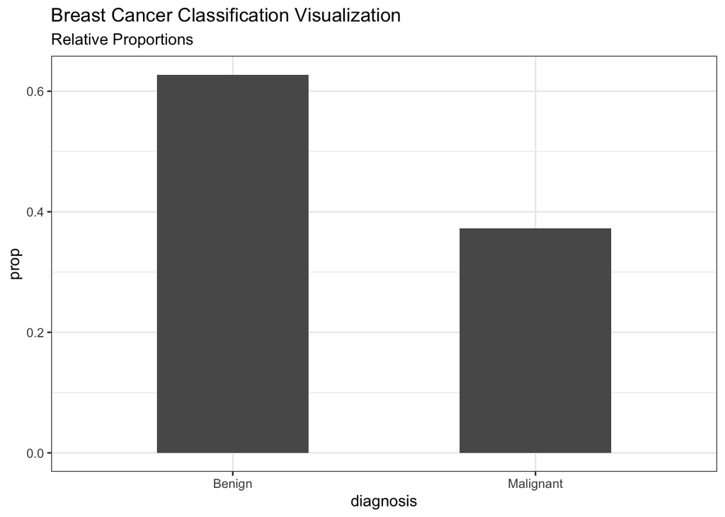

```r
## Visualization
theme_set(theme_bw())
ggplot(data = biopsy) +
  geom_bar(mapping = aes(x = diagnosis, y = ..prop..,  group=1),width=.5)+
  labs(title="Breast Cancer Classification Visualization",
       subtitle="Relative Proportions")
```

## Explore the variables of biomarkers

As indicated, therefore, all biomarkers are numerical variables, and thus exhibit results in a descriptive statistical manner.

```r
## Explore data: Summary tables for numerical variables
## HTML Output
biopsy_DS <- papeR::summarize(biopsy, type = "numeric", group = "diagnosis")
rownames(biopsy_DS) <- NULL
kable(biopsy_DS, caption = "Descriptive statistics of biomarkers", format = "html") %>%
  kable_styling(latex_options = "striped")
```

Descriptive statistics of biomarkers

|  | diagnosis |  | N |  | Mean | SD |  | Min | Q1 | Median | Q3 | Max |  | p.value |
| --- | --- | --- | --- | --- | --- | --- | --- | --- | --- | --- | --- | --- | --- | --- |
| radius_mean | Benign |  | 357 |  | 12.15 | 1.78 |  | 6.98 | 11.08 | 12.20 | 13.37 | 17.85 |  | <0.001 |
|  | Malignant |  | 212 |  | 17.46 | 3.20 |  | 10.95 | 15.07 | 17.33 | 19.59 | 28.11 |  |  |
| texture_mean | Benign |  | 357 |  | 17.91 | 4.00 |  | 9.71 | 15.15 | 17.39 | 19.76 | 33.81 |  | <0.001 |
|  | Malignant |  | 212 |  | 21.60 | 3.78 |  | 10.38 | 19.32 | 21.46 | 23.78 | 39.28 |  |  |
| perimeter_mean | Benign |  | 357 |  | 78.08 | 11.81 |  | 43.79 | 70.87 | 78.18 | 86.10 | 114.60 |  | <0.001 |
|  | Malignant |  | 212 |  | 115.37 | 21.85 |  | 71.90 | 98.71 | 114.20 | 129.95 | 188.50 |  |  |
| area_mean | Benign |  | 357 |  | 462.79 | 134.29 |  | 143.50 | 378.20 | 458.40 | 551.10 | 992.10 |  | <0.001 |
|  | Malignant |  | 212 |  | 978.38 | 367.94 |  | 361.60 | 705.00 | 932.00 | 1204.50 | 2501.00 |  |  |
| smoothness_mean | Benign |  | 357 |  | 0.09 | 0.01 |  | 0.05 | 0.08 | 0.09 | 0.10 | 0.16 |  | <0.001 |
|  | Malignant |  | 212 |  | 0.10 | 0.01 |  | 0.07 | 0.09 | 0.10 | 0.11 | 0.14 |  |  |
| compactness_mean | Benign |  | 357 |  | 0.08 | 0.03 |  | 0.02 | 0.06 | 0.08 | 0.10 | 0.22 |  | <0.001 |
|  | Malignant |  | 212 |  | 0.15 | 0.05 |  | 0.05 | 0.11 | 0.13 | 0.17 | 0.35 |  |  |
| concavity_mean | Benign |  | 357 |  | 0.05 | 0.04 |  | 0.00 | 0.02 | 0.04 | 0.06 | 0.41 |  | <0.001 |
|  | Malignant |  | 212 |  | 0.16 | 0.08 |  | 0.02 | 0.11 | 0.15 | 0.20 | 0.43 |  |  |
| concave.points_mean | Benign |  | 357 |  | 0.03 | 0.02 |  | 0.00 | 0.02 | 0.02 | 0.03 | 0.09 |  | <0.001 |
|  | Malignant |  | 212 |  | 0.09 | 0.03 |  | 0.02 | 0.06 | 0.09 | 0.10 | 0.20 |  |  |
| symmetry_mean | Benign |  | 357 |  | 0.17 | 0.02 |  | 0.11 | 0.16 | 0.17 | 0.19 | 0.27 |  | <0.001 |
|  | Malignant |  | 212 |  | 0.19 | 0.03 |  | 0.13 | 0.17 | 0.19 | 0.21 | 0.30 |  |  |
| fractal_dimension_mean | Benign |  | 357 |  | 0.06 | 0.01 |  | 0.05 | 0.06 | 0.06 | 0.07 | 0.10 |  | 0.767 |
|  | Malignant |  | 212 |  | 0.06 | 0.01 |  | 0.05 | 0.06 | 0.06 | 0.07 | 0.10 |  |  |
| radius_se | Benign |  | 357 |  | 0.28 | 0.11 |  | 0.11 | 0.21 | 0.26 | 0.34 | 0.88 |  | <0.001 |
|  | Malignant |  | 212 |  | 0.61 | 0.35 |  | 0.19 | 0.39 | 0.55 | 0.76 | 2.87 |  |  |
| texture_se | Benign |  | 357 |  | 1.22 | 0.59 |  | 0.36 | 0.80 | 1.11 | 1.49 | 4.88 |  | 0.835 |
|  | Malignant |  | 212 |  | 1.21 | 0.48 |  | 0.36 | 0.89 | 1.10 | 1.43 | 3.57 |  |  |
| perimeter_se | Benign |  | 357 |  | 2.00 | 0.77 |  | 0.76 | 1.45 | 1.85 | 2.39 | 5.12 |  | <0.001 |
|  | Malignant |  | 212 |  | 4.32 | 2.57 |  | 1.33 | 2.70 | 3.68 | 5.21 | 21.98 |  |  |
| area_se | Benign |  | 357 |  | 21.14 | 8.84 |  | 6.80 | 15.26 | 19.63 | 25.03 | 77.11 |  | <0.001 |
|  | Malignant |  | 212 |  | 72.67 | 61.36 |  | 13.99 | 35.76 | 58.45 | 94.01 | 542.20 |  |  |
| smoothness_se | Benign |  | 357 |  | 0.01 | 0.00 |  | 0.00 | 0.01 | 0.01 | 0.01 | 0.02 |  | 0.105 |
|  | Malignant |  | 212 |  | 0.01 | 0.00 |  | 0.00 | 0.01 | 0.01 | 0.01 | 0.03 |  |  |
| compactness_se | Benign |  | 357 |  | 0.02 | 0.02 |  | 0.00 | 0.01 | 0.02 | 0.03 | 0.11 |  | <0.001 |
|  | Malignant |  | 212 |  | 0.03 | 0.02 |  | 0.01 | 0.02 | 0.03 | 0.04 | 0.14 |  |  |
| concavity_se | Benign |  | 357 |  | 0.03 | 0.03 |  | 0.00 | 0.01 | 0.02 | 0.03 | 0.40 |  | <0.001 |
|  | Malignant |  | 212 |  | 0.04 | 0.02 |  | 0.01 | 0.03 | 0.04 | 0.05 | 0.14 |  |  |
| concave.points_se | Benign |  | 357 |  | 0.01 | 0.01 |  | 0.00 | 0.01 | 0.01 | 0.01 | 0.05 |  | <0.001 |
|  | Malignant |  | 212 |  | 0.02 | 0.01 |  | 0.01 | 0.01 | 0.01 | 0.02 | 0.04 |  |  |
| symmetry_se | Benign |  | 357 |  | 0.02 | 0.01 |  | 0.01 | 0.02 | 0.02 | 0.02 | 0.06 |  | 0.887 |
|  | Malignant |  | 212 |  | 0.02 | 0.01 |  | 0.01 | 0.01 | 0.02 | 0.02 | 0.08 |  |  |
| fractal_dimension_se | Benign |  | 357 |  | 0.00 | 0.00 |  | 0.00 | 0.00 | 0.00 | 0.00 | 0.03 |  | 0.042 |
|  | Malignant |  | 212 |  | 0.00 | 0.00 |  | 0.00 | 0.00 | 0.00 | 0.00 | 0.01 |  |  |
| radius_worst | Benign |  | 357 |  | 13.38 | 1.98 |  | 7.93 | 12.08 | 13.35 | 14.80 | 19.82 |  | <0.001 |
|  | Malignant |  | 212 |  | 21.13 | 4.28 |  | 12.84 | 17.73 | 20.59 | 23.82 | 36.04 |  |  |
| texture_worst | Benign |  | 357 |  | 23.52 | 5.49 |  | 12.02 | 19.58 | 22.82 | 26.51 | 41.78 |  | <0.001 |
|  | Malignant |  | 212 |  | 29.32 | 5.43 |  | 16.67 | 25.76 | 28.94 | 32.70 | 49.54 |  |  |
| perimeter_worst | Benign |  | 357 |  | 87.01 | 13.53 |  | 50.41 | 78.27 | 86.92 | 96.59 | 127.10 |  | <0.001 |
|  | Malignant |  | 212 |  | 141.37 | 29.46 |  | 85.10 | 119.25 | 138.00 | 159.80 | 251.20 |  |  |
| area_worst | Benign |  | 357 |  | 558.90 | 163.60 |  | 185.20 | 447.10 | 547.40 | 670.00 | 1210.00 |  | <0.001 |
|  | Malignant |  | 212 |  | 1422.29 | 597.97 |  | 508.10 | 969.20 | 1303.00 | 1716.50 | 4254.00 |  |  |
| smoothness_worst | Benign |  | 357 |  | 0.12 | 0.02 |  | 0.07 | 0.11 | 0.13 | 0.14 | 0.20 |  | <0.001 |
|  | Malignant |  | 212 |  | 0.14 | 0.02 |  | 0.09 | 0.13 | 0.14 | 0.16 | 0.22 |  |  |
| compactness_worst | Benign |  | 357 |  | 0.18 | 0.09 |  | 0.03 | 0.11 | 0.17 | 0.23 | 0.58 |  | <0.001 |
|  | Malignant |  | 212 |  | 0.37 | 0.17 |  | 0.05 | 0.24 | 0.36 | 0.45 | 1.06 |  |  |
| concavity_worst | Benign |  | 357 |  | 0.17 | 0.14 |  | 0.00 | 0.08 | 0.14 | 0.22 | 1.25 |  | <0.001 |
|  | Malignant |  | 212 |  | 0.45 | 0.18 |  | 0.02 | 0.33 | 0.40 | 0.56 | 1.17 |  |  |
| concave.points_worst | Benign |  | 357 |  | 0.07 | 0.04 |  | 0.00 | 0.05 | 0.07 | 0.10 | 0.17 |  | <0.001 |
|  | Malignant |  | 212 |  | 0.18 | 0.05 |  | 0.03 | 0.15 | 0.18 | 0.21 | 0.29 |  |  |
| symmetry_worst | Benign |  | 357 |  | 0.27 | 0.04 |  | 0.16 | 0.24 | 0.27 | 0.30 | 0.42 |  | <0.001 |
|  | Malignant |  | 212 |  | 0.32 | 0.07 |  | 0.16 | 0.28 | 0.31 | 0.36 | 0.66 |  |  |
| fractal_dimension_worst | Benign |  | 357 |  | 0.08 | 0.01 |  | 0.06 | 0.07 | 0.08 | 0.09 | 0.15 |  | <0.001 |
|  | Malignant |  | 212 |  | 0.09 | 0.02 |  | 0.06 | 0.08 | 0.09 | 0.10 | 0.21 |  |  |

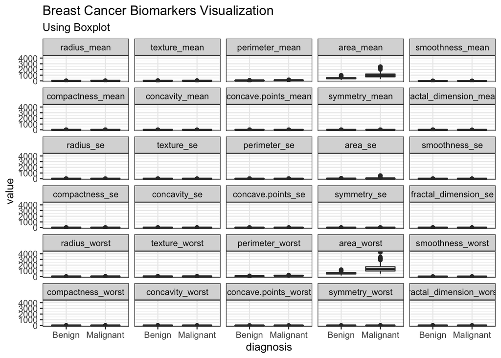

```r
biopsy.m <- melt(biopsy, id.var = "diagnosis")
ggplot(data = biopsy.m, aes(x = diagnosis, y = value)) +
  geom_boxplot() + facet_wrap(~ variable, ncol = 5) +
  labs(title="Breast Cancer Biomarkers Visualization",
       subtitle="Using Boxplot")+
  theme(legend.position="top")
```

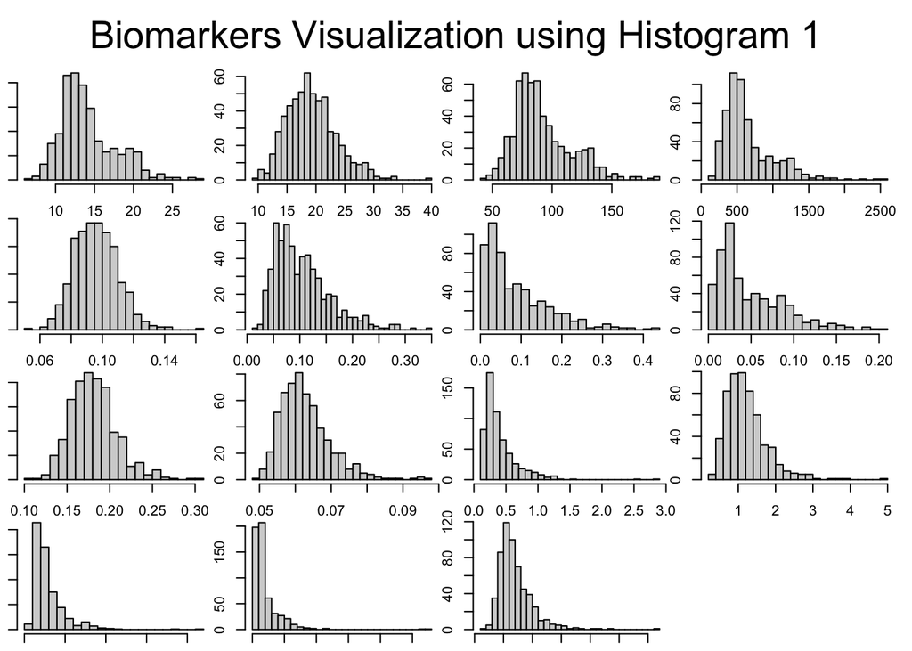

```r
par(mar=c(1,1,1,1))
hist.data.frame(biopsy[,c(2:16)], n.unique=1,
                mtitl = "Biomarkers Visualization using Histogram 1")
```

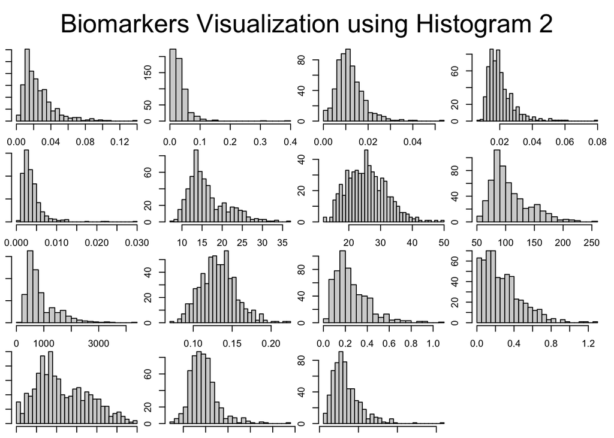

```r
hist.data.frame(biopsy[,c(17:31)], n.unique=1,
                mtitl = "Biomarkers Visualization using Histogram 2")
```

## Feature scaling using z-score

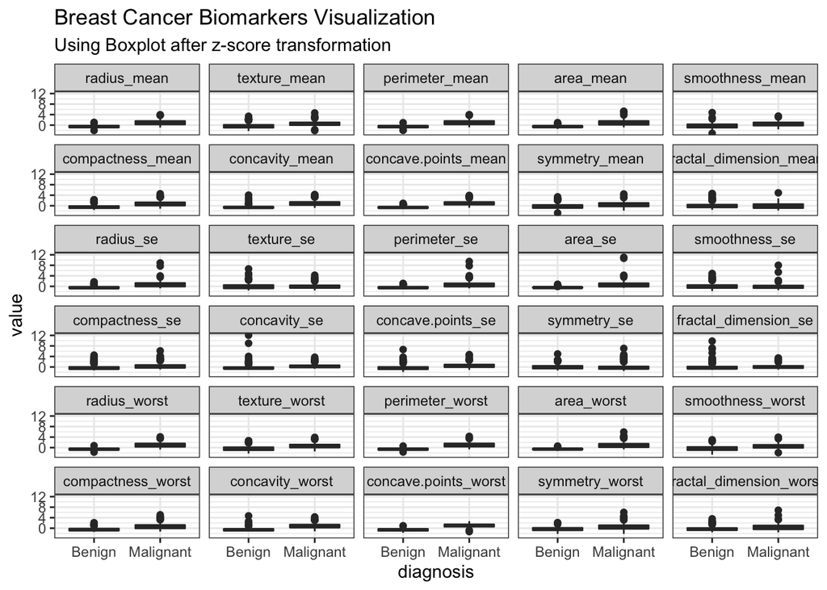

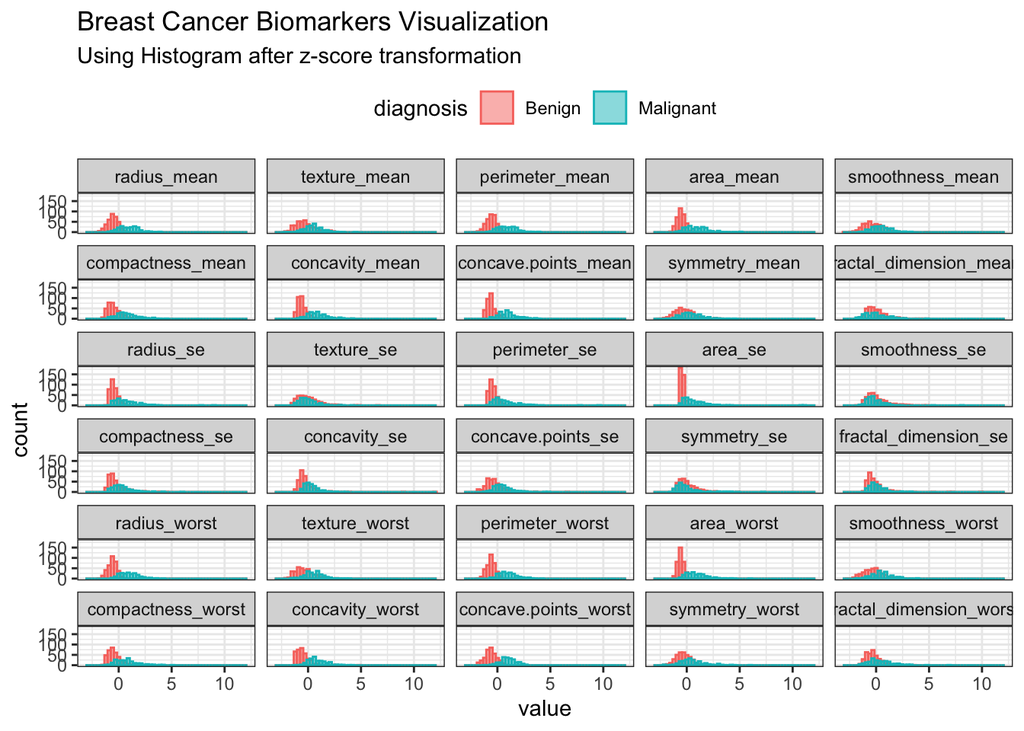

**Note**: Other conversion (normalization) can also be considered, as follows, the values of all biomarkers fall in the interval [0, 1], this document only uses z-score conversion.

```
normalize <- function(x) {
  return ((x - min(x)) / (max(x) - min(x)))
}
biopsy_NM <- biopsy
biopsy_NM[-1]<- as.data.frame(lapply(biopsy[-1], normalize))
```

## Summary of the data exploration

- No missing values.
- Except for the variables fractal_dimension_mean, texture_se, smoothness_se, symmetry_se, other biomarkers differ significantly between diagnoses.
- As shown in Boxplot Histogram, the measurement scale of some biomarkers is very large, such as area_mean, area_worst, which may cause problems in the classification algorithm, so all variables will be scaled to the standard value using z-score transformation.
- Most histograms are distributed asymmetrically, similar to exponential distributions.

# Correlation Exploration

## Correlation structure

Correlation of biomarkers greater than 0.9

| row | column | cor |
| --- | --- | --- |
| radius_mean | perimeter_mean | 0.998 |
| radius_mean | area_mean | 0.987 |
| perimeter_mean | area_mean | 0.987 |
| concavity_mean | concave.points_mean | 0.921 |
| radius_se | perimeter_se | 0.973 |
| radius_se | area_se | 0.952 |
| perimeter_se | area_se | 0.938 |
| radius_mean | radius_worst | 0.970 |
| perimeter_mean | radius_worst | 0.969 |
| area_mean | radius_worst | 0.963 |
| texture_mean | texture_worst | 0.912 |
| radius_mean | perimeter_worst | 0.965 |
| perimeter_mean | perimeter_worst | 0.970 |
| area_mean | perimeter_worst | 0.959 |
| radius_worst | perimeter_worst | 0.994 |
| radius_mean | area_worst | 0.941 |
| perimeter_mean | area_worst | 0.942 |
| area_mean | area_worst | 0.959 |
| radius_worst | area_worst | 0.984 |
| perimeter_worst | area_worst | 0.978 |
| concave.points_mean | concave.points_worst | 0.910 |

[figure not shown]

## Summary of the correlation exploration

The correlation between variables should not be ignored. 21 pairs of highly correlated biomarkers are found, with correlation coefficients greater than 0.9, which would lead to multicollinearity problems.

# Biomarker Candidates Identification and Modeling

## Idea

The target variable “diagnosis” is a binary variable. Therefore, in order to identify biomarker candidates related to the classification of benign and malignant cancers, different classification algorithms can be used for modeling. Here, the following variable screening/modeling methods are compared.

1. Scenario 1: Logistic regression using full model including all biomarkers.
2. Scenario 2: Logistic regression, delete highly correlated biomarker variables in the full model.
3. Scenario 3: Logistic regression using model selection (backward) to reduce the characteristics of biomarkers from the full model and from the model after removing high-correlation terms.
4. Scenario 4: Regularized logistic regression using lasso regularization
5. Scenario 5: Regularized logistic regression using elastic net regularization
6. Scenario 6: Multiple adaptive regression splines (MARS)

In addition, in order to provide a more comprehensive comparison (here is no clear biomarker identification), the following machine learning methods will be introduced.

1. Linear discriminant analysis (LDA)
2. Principal component analysis (PCA)
3. Support Vector Machine (SVM)
4. K-Nearest Neighbors (KNN)
5. Random Forest (RF)

## Data Preparation

In order to evaluate the predictive ability of the model, the data set is divided into a training data set (70%) and a test data set (30%). The training data set is used to build the model, and the test data set is used to detect the predictive ability of the model.

```r
set.seed(123)
ind <- sample(2, nrow(biopsy_ZS), replace = TRUE, prob = c(0.7, 0.3))
## the training data set with 70% data
biopsy.zs.train <- biopsy_ZS[ind == 1, ]
## the test data set with 30% data
biopsy.zs.test <- biopsy_ZS[ind == 2, ]

trainY <- biopsy_ZS$diagnosis[ind==1]
testY <-  biopsy_ZS$diagnosis[ind==2]

## Recode the diagnosis as numeric Benign 0 or Malignant 1
y_train <- ifelse(biopsy.zs.train$diagnosis == "Malignant",1,0)
y_test <- ifelse(biopsy.zs.test$diagnosis == "Malignant",1,0)
```

## Modeling

### Scenario 1: Logistic regression (Full Model)

```r
LR.full.fit <- glm(diagnosis ~ ., family = binomial, data = biopsy.zs.train)

## view the coefficients of each predictor and its p-value
summary(LR.full.fit)
```

```
##
## Call:
## glm(formula = diagnosis ~ ., family = binomial, data = biopsy.zs.train)
##
## Deviance Residuals:
##        Min          1Q      Median          3Q         Max
## -1.697e-04  -2.100e-08  -2.100e-08   2.100e-08   1.885e-04
##
## Coefficients:
##                           Estimate Std. Error z value Pr(>|z|)
## (Intercept)                 10.188  22004.408   0.000    1.000
## radius_mean              -1628.946 790630.076  -0.002    0.998
## texture_mean               120.671  30631.648   0.004    0.997
## perimeter_mean             922.254 685327.455   0.001    0.999
## area_mean                  506.050 430250.582   0.001    0.999
## smoothness_mean            136.496  27414.428   0.005    0.996
## compactness_mean          -314.127  90895.572  -0.003    0.997
## concavity_mean             348.563 102101.477   0.003    0.997
## concave.points_mean       -132.201 115957.194  -0.001    0.999
## symmetry_mean              -46.430  12941.595  -0.004    0.997
## fractal_dimension_mean      -8.371  26063.428   0.000    1.000
## radius_se                 -103.475 123574.398  -0.001    0.999
## texture_se                  64.122  22582.706   0.003    0.998
## perimeter_se                34.770  32367.714   0.001    0.999
## area_se                     39.958 196718.773   0.000    1.000
## smoothness_se              -66.975  28926.939  -0.002    0.998
## compactness_se             122.822  53281.738   0.002    0.998
## concavity_se                12.369  47216.840   0.000    1.000
## concave.points_se          161.502  32427.052   0.005    0.996
## symmetry_se                -21.266  16992.467  -0.001    0.999
## fractal_dimension_se      -249.656  53333.402  -0.005    0.996
## radius_worst              1338.505 393767.432   0.003    0.997
## texture_worst              -80.762  39768.728  -0.002    0.998
## perimeter_worst           -663.404 249446.073  -0.003    0.998
## area_worst                -185.615 327445.067  -0.001    1.000
## smoothness_worst            -7.334  22648.150   0.000    1.000
## compactness_worst          -13.885  69428.015   0.000    1.000
## concavity_worst           -166.540  57446.632  -0.003    0.998
## concave.points_worst        90.685  85945.881   0.001    0.999
## symmetry_worst              64.122  32643.012   0.002    0.998
## fractal_dimension_worst    169.356  36779.093   0.005    0.996
##
## (Dispersion parameter for binomial family taken to be 1)
##
##     Null deviance: 5.2474e+02  on 404  degrees of freedom
## Residual deviance: 2.8267e-07  on 374  degrees of freedom
## AIC: 62
##
## Number of Fisher Scoring iterations: 25
```

```r
## 95% confidence interval
confint(LR.full.fit)
```

```
##                               2.5 %     97.5 %
## (Intercept)               -903.0296   895.1982
## radius_mean             -39781.1822 34955.3149
## texture_mean             -1100.4165  1323.9173
## perimeter_mean          -26641.3880 29364.4332
## area_mean               -16967.3472 17219.3645
## smoothness_mean           -904.4123  1206.8174
## compactness_mean         -3693.7761  3110.3161
## concavity_mean           -4228.9028  5015.0447
## concave.points_mean      -4602.1856  4687.0213
## symmetry_mean             -543.8882   451.0279
## fractal_dimension_mean   -1047.3534  1015.4298
## radius_se                -5204.5377  5261.9185
## texture_se                -940.7240  1033.5312
## perimeter_se             -1629.9299  1587.6602
## area_se                  -7949.2127  7681.6040
## smoothness_se            -1220.1064  1069.3086
## compactness_se           -1837.9698  2163.0811
## concavity_se             -1868.4236  2016.5251
## concave.points_se         -997.7298  1380.8036
## symmetry_se               -713.6782   614.1895
## fractal_dimension_se     -2127.3144  1585.7221
## radius_worst            -16882.0143 20339.9425
## texture_worst            -1664.8737  1607.2527
## perimeter_worst         -10402.3470  8807.9005
## area_worst              -13048.0317 12867.5229
## smoothness_worst          -896.9788   895.5032
## compactness_worst        -2895.2579  2778.4868
## concavity_worst          -2330.8116  1969.4219
## concave.points_worst     -2887.9281  2885.9527
## symmetry_worst           -1095.6736  1316.5076
## fractal_dimension_worst  -1330.1420  1668.8543
```

```r
## Calculate VIF statistics
vif(LR.full.fit)
```

```
##             radius_mean            texture_mean          perimeter_mean
##             32779.90248               301.78667             24970.96654
##               area_mean         smoothness_mean        compactness_mean
##              6868.51389               141.60247              2019.09841
##          concavity_mean     concave.points_mean           symmetry_mean
##              1204.18783               928.92418                43.80796
##  fractal_dimension_mean               radius_se              texture_se
##               159.93214              1171.88699               155.76136
##            perimeter_se                 area_se           smoothness_se
##                86.14020               775.58470               202.81273
##          compactness_se            concavity_se       concave.points_se
##              1908.91541               533.43324               259.35766
##             symmetry_se    fractal_dimension_se            radius_worst
##               102.13595               744.91495              5094.97442
##           texture_worst         perimeter_worst              area_worst
##               444.53179              2307.27972              2273.64456
##        smoothness_worst       compactness_worst         concavity_worst
##                85.18255              2002.87922               718.39845
##    concave.points_worst          symmetry_worst fractal_dimension_worst
##               697.03622               355.88401               540.74007
```

**Finding:**

- The algorithm does not converge.
- It can be seen from the correlation coefficient and VIF statistics (much greater than 5) that there will be a problem of collinearity.
- All predictors are not significant, the coefficient is too large, and the confidence interval is too wide. The full model did not provide any meaningful results and will not be evaluated.

### Scenario 2: Logistic regression (removing highly correlated items)

In the previous exploration of the data, 21 pairs of biomarkers were found to have high correlations, greater than 0.9. In order to avoid the problem of collinearity caused by high correlation, the following variables are removed from the full model and the model is re-modeled using logistic regression.

*radius_mean, perimeter_mean, area_mean, concave.points_mean, radius_se,area_se, compactness_se, texture_worst, perimeter_worst, area_worst*

```r
## Fisrt check the correlation of biomarkers after removing
new_cor <- CorrMatrixtable(round(cor(biopsy_ZS[-c(1,2,4,5,9,12,15,17,23,24,25)]), 3))
new_cor[new_cor$cor>0.9,]
```

| row | column | cor |
| --- | --- | --- |

```r
## Modeling
LR.cor.fit <- glm(diagnosis ~ ., family = binomial, data = biopsy.zs.train[-c(2,4,5,9,12,15,17,23,24,25)])

## view the coefficients of each predictor and its p-value
summary(LR.cor.fit)
```

```
##
## Call:
## glm(formula = diagnosis ~ ., family = binomial, data = biopsy.zs.train[-c(2,
##     4, 5, 9, 12, 15, 17, 23, 24, 25)])
##
## Deviance Residuals:
##     Min       1Q   Median       3Q      Max
## -1.6383  -0.0011   0.0000   0.0000   3.2927
##
## Coefficients:
##                           Estimate Std. Error z value Pr(>|z|)
## (Intercept)              -0.007041   1.405268  -0.005  0.99600
## texture_mean              5.192877   2.093409   2.481  0.01312 *
## smoothness_mean           8.587731   4.180121   2.054  0.03993 *
## compactness_mean        -27.470311  13.319848  -2.062  0.03917 *
## concavity_mean           14.832439   9.009405   1.646  0.09970 .
## symmetry_mean            -0.944000   2.229587  -0.423  0.67201
## fractal_dimension_mean    4.045784   3.361026   1.204  0.22869
## texture_se                1.538233   1.049050   1.466  0.14256
## perimeter_se              5.615655   3.811098   1.474  0.14062
## smoothness_se            -0.390916   1.503370  -0.260  0.79484
## concavity_se              7.908099   6.304645   1.254  0.20972
## concave.points_se         5.011862   4.909807   1.021  0.30736
## symmetry_se               2.302005   2.037779   1.130  0.25862
## fractal_dimension_se    -18.115609   8.915028  -2.032  0.04215 *
## radius_worst             18.953117   7.319922   2.589  0.00962 **
## smoothness_worst         -0.695951   2.376437  -0.293  0.76963
## compactness_worst         8.723578   7.790081   1.120  0.26279
## concavity_worst         -10.041809   6.608611  -1.520  0.12864
## concave.points_worst      2.166994   6.263445   0.346  0.72936
## symmetry_worst           -0.087754   2.570591  -0.034  0.97277
## fractal_dimension_worst  13.606002   5.734680   2.373  0.01766 *
## ---
## Signif. codes:  0 '***' 0.001 '**' 0.01 '*' 0.05 '.' 0.1 ' ' 1
##
## (Dispersion parameter for binomial family taken to be 1)
##
##     Null deviance: 524.741  on 404  degrees of freedom
## Residual deviance:  25.307  on 384  degrees of freedom
## AIC: 67.307
##
## Number of Fisher Scoring iterations: 13
```

```r
## 95% confidence interval
confint(LR.cor.fit)
```

```
##                                2.5 %     97.5 %
## (Intercept)              -2.96239659  3.0316836
## texture_mean              2.23852084 11.5751202
## smoothness_mean           2.53247898 21.4600128
## compactness_mean        -65.29872490 -8.2384338
## concavity_mean            1.04622843 37.6711886
## symmetry_mean            -6.78855236  3.3164730
## fractal_dimension_mean   -2.05497699 12.2612941
## texture_se               -0.37285761  4.2175957
## perimeter_se             -0.04671004 17.1981594
## smoothness_se            -3.82883326  3.1126911
## concavity_se             -0.98023390 26.2968613
## concave.points_se        -3.67033569 17.1122844
## symmetry_se              -1.67932611  7.1871422
## fractal_dimension_se    -45.20146522 -5.9457494
## radius_worst              8.07178305 39.7015610
## smoothness_worst         -6.15570009  3.8357675
## compactness_worst        -3.57523816 29.8743058
## concavity_worst         -29.96333100  0.4843902
## concave.points_worst    -11.13066456 16.5893438
## symmetry_worst           -6.17797335  5.4276224
## fractal_dimension_worst   4.62590620 29.5759551
```

```r
## Calculate VIF statistics
vif(LR.cor.fit)
```

```
##            texture_mean         smoothness_mean        compactness_mean
##               15.634579               38.025024              428.543010
##          concavity_mean           symmetry_mean  fractal_dimension_mean
##              116.780378               16.900487               33.507359
##              texture_se            perimeter_se           smoothness_se
##                3.937893               10.854929               14.292079
##            concavity_se       concave.points_se             symmetry_se
##              270.218155               82.652936               17.084142
##    fractal_dimension_se            radius_worst        smoothness_worst
##              462.998140               28.575337               12.123885
##       compactness_worst         concavity_worst    concave.points_worst
##              309.677531              122.134138               33.668617
##          symmetry_worst fractal_dimension_worst
##               32.295338              162.878671
```

```r
## Performance on the test dataset
LR.cor.probs <- predict(LR.cor.fit, newdata = biopsy.zs.test, type = "response")

## Calculate the confusion matrix
InformationValue::confusionMatrix(testY, LR.cor.probs)
```

|  | Benign | Malignant |
| --- | --- | --- |
| 0 | 85 | 7 |
| 1 | 9 | 63 |

### Scenario 3: Logistic regression (backward seletion)

In Scenario 1 and Scenario 2, all variables of the full model are not significant, and after removing highly correlated variables, most models are still not significant. Therefore, backward logistic regression is used here to select the best model for the two models. The selection criteria is AIC.

```r
## Selection from the full model of Scenario 1
backward.full <- stepAIC(LR.full.fit, direction = "backward", trace = FALSE)
backward.full$formula
```

```
## diagnosis ~ radius_mean + texture_mean + smoothness_mean + compactness_mean +
##     concavity_mean + smoothness_se + compactness_se + concave.points_se +
##     fractal_dimension_se + radius_worst + perimeter_worst + concavity_worst +
##     fractal_dimension_worst
```

```r
LR.Bestfull.fit <- glm(backward.full$formula, family = binomial,
                       data = biopsy.zs.train)
summary(LR.Bestfull.fit)
```

```
##
## Call:
## glm(formula = backward.full$formula, family = binomial, data = biopsy.zs.train)
##
## Deviance Residuals:
##        Min          1Q      Median          3Q         Max
## -8.458e-04  -2.000e-08  -2.000e-08   2.000e-08   9.000e-04
##
## Coefficients:
##                          Estimate Std. Error z value Pr(>|z|)
## (Intercept)                -90.55    2954.97  -0.031    0.976
## radius_mean              -1435.44   49645.19  -0.029    0.977
## texture_mean               384.96   11759.39   0.033    0.974
## smoothness_mean            522.43   15635.31   0.033    0.973
## compactness_mean         -1490.33   45396.70  -0.033    0.974
## concavity_mean            1031.79   31188.51   0.033    0.974
## smoothness_se             -220.70    6937.06  -0.032    0.975
## compactness_se             397.44   12791.05   0.031    0.975
## concave.points_se          783.22   23479.84   0.033    0.973
## fractal_dimension_se      -969.75   29024.92  -0.033    0.973
## radius_worst              3900.74  131700.04   0.030    0.976
## perimeter_worst          -1490.36   52991.33  -0.028    0.978
## concavity_worst           -208.33    6969.25  -0.030    0.976
## fractal_dimension_worst    809.37   24043.44   0.034    0.973
##
## (Dispersion parameter for binomial family taken to be 1)
##
##     Null deviance: 5.2474e+02  on 404  degrees of freedom
## Residual deviance: 3.9533e-06  on 391  degrees of freedom
## AIC: 28
##
## Number of Fisher Scoring iterations: 25
```

```r
## Selection from the model of Scenario 2
backward.cor <- stepAIC(LR.cor.fit, direction = "backward", trace = FALSE)
backward.cor$formula
```

```
## diagnosis ~ texture_mean + smoothness_mean + compactness_mean +
##     concavity_mean + texture_se + perimeter_se + concave.points_se +
##     symmetry_se + fractal_dimension_se + radius_worst + fractal_dimension_worst
```

```r
LR.Bestcor.fit <- glm(backward.cor$formula, family = binomial,
                       data = biopsy.zs.train)
summary(LR.Bestcor.fit)
```

```
##
## Call:
## glm(formula = backward.cor$formula, family = binomial, data = biopsy.zs.train)
##
## Deviance Residuals:
##     Min       1Q   Median       3Q      Max
## -1.7388  -0.0113  -0.0003   0.0000   3.2148
##
## Coefficients:
##                         Estimate Std. Error z value Pr(>|z|)
## (Intercept)               0.2103     0.7455   0.282 0.777873
## texture_mean              3.1536     1.0694   2.949 0.003190 **
## smoothness_mean           4.8060     1.6804   2.860 0.004235 **
## compactness_mean        -12.0622     3.9506  -3.053 0.002264 **
## concavity_mean            6.7398     2.8410   2.372 0.017675 *
## texture_se                1.3776     0.7782   1.770 0.076691 .
## perimeter_se              3.0795     1.8999   1.621 0.105051
## concave.points_se         4.3587     1.7276   2.523 0.011637 *
## symmetry_se               1.7404     0.8607   2.022 0.043161 *
## fractal_dimension_se     -8.2000     2.7295  -3.004 0.002662 **
## radius_worst             11.9884     3.3743   3.553 0.000381 ***
## fractal_dimension_worst   9.0973     2.8151   3.232 0.001231 **
## ---
## Signif. codes:  0 '***' 0.001 '**' 0.01 '*' 0.05 '.' 0.1 ' ' 1
##
## (Dispersion parameter for binomial family taken to be 1)
##
##     Null deviance: 524.741  on 404  degrees of freedom
## Residual deviance:  30.872  on 393  degrees of freedom
## AIC: 54.872
##
## Number of Fisher Scoring iterations: 11
```

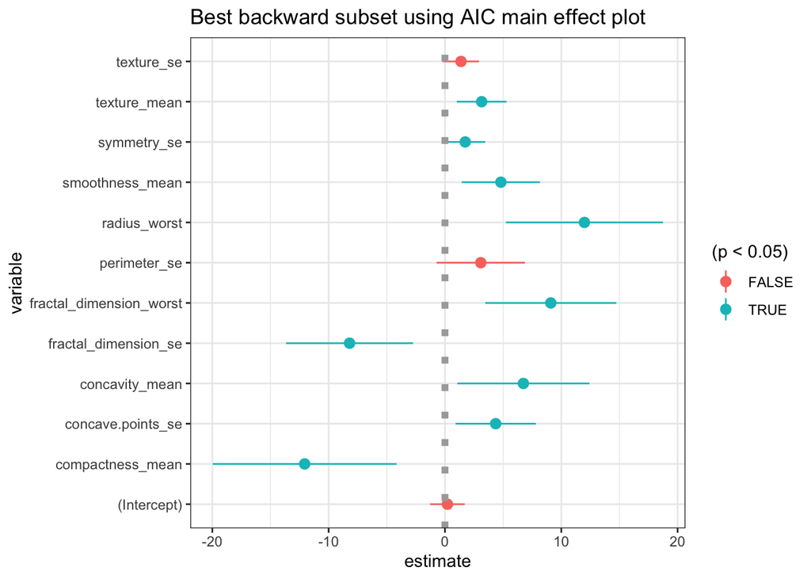

```r
## Plot the main effect
beta.table <- data.frame(summary(LR.Bestcor.fit)$coef)
beta.table$variable <- row.names(beta.table)
beta.table <- mutate(beta.table, estimate = Estimate,
                     se = Std..Error,
                     low = Estimate - 2*se,
                     high = Estimate + 2*se,
                     p = Pr...z..)

ggplot(beta.table, aes(y=estimate, x=variable, ymin=low, ymax=high, color = (p < 0.05))) +
  geom_pointrange() +
  geom_hline(yintercept = 0, col="darkgrey", lty = 3, lwd=2) +
  coord_flip() + ggtitle("Best backward subset using AIC main effect plot")
```

```r
## Performance on the test dataset
LR.Bestcor.probs <- predict(LR.Bestcor.fit, newdata = biopsy.zs.test, type = "response")

## Calculate the confusion matrix
InformationValue::confusionMatrix(testY, LR.Bestcor.probs)
```

|  | Benign | Malignant |
| --- | --- | --- |
| 0 | 86 | 5 |
| 1 | 8 | 65 |

**Finding:**

- For the Scenario 1 full model, the algorithm does not converge after the model selection, and all the variables are still insignificant.
- For the Scenario 2 model, the algorithm converges after the model is selected, and most of the variables are significant, and the confidence interval does not include 0. Model comparison is possible to verify whether the fitted model has good performance on the test data set.

### Scenario 4: Lasso regression

For high-dimensional data, techniques such as best subsets and stepwise feature selection will cause unbearable time costs. If we use the best subset method, we need to test 2<sup>30</sup> models on a breast cancer data set. For which regularization is a very convenient method. For the determined parameter lambda, the model only needs to be executed once using penalized regression, so the efficiency will be greatly improved. Regularization can limit the coefficients and even reduces them to 0 to reduce the variable characteristics. In addition, regularization can also handle high correlations between variables, to solve the problem of multicollinearity.

Two regularization techniques are used for modeling here, namely Lasso regression (Scenario 4) and Elastic net (Scenario 5).

Lasso regression uses L1-norm, that is, to minimize $RSS + \lambda(\sum|\beta_j|)$ as following. This shrinkage penalty term can shrink the feature weight to 0 compared to ridge regression to reduce the variable.

$$\sum_{i=1}^{n}\left(y_{i}-\sum_{j} x_{i j} \beta_{j}\right)^{2}+\lambda \sum_{j=1}^{p}\left|\beta_{j}\right|$$
In order to better reduce the error, cross-validation is used here for lasso regression.

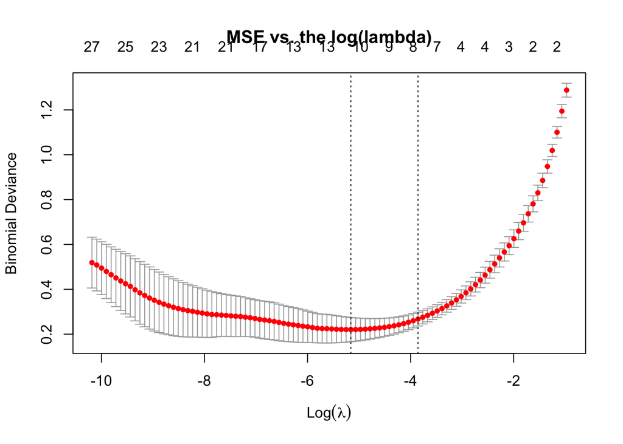

```r
## Lasso Regression
## 3-fold cross-validation
set.seed(317)
lasso.cv = cv.glmnet(x=as.matrix(biopsy.zs.train[-1]), y=y_train,
                     family = "binomial",  nfolds = 3)

## The two vertical dashed lines in the figure represent the log(lambda) of
## the minimum MSE (the dashed line on the left) and the log(lambda) of one standard error of the minimum distance.
plot(lasso.cv,main="MSE vs. the log(lambda)")
```

```r
## minimum
lasso.cv$lambda.min
```

```
## [1] 0.005745832
```

```r
## show the fitted model
lasso.fit <- glmnet(x=as.matrix(biopsy.zs.train[-1]), y=y_train,
                    family = "binomial",
                    alpha = 1,
                    lambda =lasso.cv$lambda.min)
coef(lasso.fit)
```

```
## 31 x 1 sparse Matrix of class "dgCMatrix"
##                                   s0
## (Intercept)             -0.697616943
## radius_mean              .
## texture_mean             0.554494451
## perimeter_mean           .
## area_mean                .
## smoothness_mean          .
## compactness_mean         .
## concavity_mean           .
## concave.points_mean      0.433037538
## symmetry_mean            .
## fractal_dimension_mean   .
## radius_se                1.605347154
## texture_se               .
## perimeter_se             .
## area_se                  .
## smoothness_se            0.004865844
## compactness_se          -0.134385160
## concavity_se             .
## concave.points_se        .
## symmetry_se              .
## fractal_dimension_se    -0.210251931
## radius_worst             2.386743722
## texture_worst            0.834411163
## perimeter_worst          .
## area_worst               .
## smoothness_worst         0.554984314
## compactness_worst        .
## concavity_worst          .
## concave.points_worst     1.926070003
## symmetry_worst           0.167379412
## fractal_dimension_worst  .
```

```r
## Predict on the test dataset
lasso.probs <- predict(lasso.cv, newx=as.matrix(biopsy.zs.test[-1]),
                       type = "response",
                       s = "lambda.min")

## Calculate the confusion matrix
InformationValue::confusionMatrix(testY, lasso.probs)
```

|  | Benign | Malignant |
| --- | --- | --- |
| 0 | 93 | 5 |
| 1 | 1 | 65 |

**Finding:**

- Model dimensions are significantly reduced.

### Scenario 5: Elastic net regularization

Elastic Net combines the advantages of Ridge regression and Lasso regression, using L1 and L2 norms as following

$${\displaystyle {\hat {\beta }}\equiv {\underset {\beta }{\operatorname {argmin} }}(\|y-X\beta \|^{2}+\lambda _{2}\|\beta \|^{2}+\lambda _{1}\|\beta \|_{1}).}.$$

For the parameter a, a = 0 represents the ridge regression penalty, and a = 1 represents the Lasso penalty. A grid is established here to find the best a and lambda. The final values used for the model were alpha = 0.2 and lambda = 0.02.

```r
## Elastic net regularization
grid <- expand.grid(.alpha = seq(0,1, by=.2),
                    .lambda = seq(0.00, 0.2, by = 0.02))

## Leave-One-Out Cross-Validation
## FInd the best alpha and lambda with smallest MAE
control <- trainControl(method = "LOOCV")
set.seed(701)
enet.train = train(diagnosis ~ ., data = biopsy.zs.train,
                   method = "glmnet",
                   family = "binomial",
                   trControl = control,
                   tuneGrid = grid)
enet.train
```

```
## glmnet
##
## 405 samples
##  30 predictor
##   2 classes: 'Benign', 'Malignant'
##
## No pre-processing
## Resampling: Leave-One-Out Cross-Validation
## Summary of sample sizes: 404, 404, 404, 404, 404, 404, ...
## Resampling results across tuning parameters:
##
##   alpha  lambda  Accuracy   Kappa
##   0.0    0.00    0.9703704  0.9338614
##   0.0    0.02    0.9703704  0.9338614
##   0.0    0.04    0.9703704  0.9338614
##   0.0    0.06    0.9679012  0.9282316
##   0.0    0.08    0.9679012  0.9282316
##   0.0    0.10    0.9629630  0.9169163
##   0.0    0.12    0.9580247  0.9055257
##   0.0    0.14    0.9580247  0.9055257
##   0.0    0.16    0.9530864  0.8940593
##   0.0    0.18    0.9530864  0.8940593
##   0.0    0.20    0.9555556  0.8994677
##   0.2    0.00    0.9679012  0.9289349
##   0.2    0.02    0.9777778  0.9506399
##   0.2    0.04    0.9703704  0.9338614
##   0.2    0.06    0.9679012  0.9282316
##   0.2    0.08    0.9604938  0.9112304
##   0.2    0.10    0.9555556  0.8998021
##   0.2    0.12    0.9555556  0.8994677
##   0.2    0.14    0.9530864  0.8937052
##   0.2    0.16    0.9506173  0.8879234
##   0.2    0.18    0.9456790  0.8763015
##   0.2    0.20    0.9456790  0.8763015
##   0.4    0.00    0.9679012  0.9289349
##   0.4    0.02    0.9777778  0.9506399
##   0.4    0.04    0.9703704  0.9338614
##   0.4    0.06    0.9654321  0.9225833
##   0.4    0.08    0.9580247  0.9052110
##   0.4    0.10    0.9555556  0.8994677
```

[output cut: 26 more lines]

```
##   0.8    0.20    0.8913580  0.7431092
##   1.0    0.00    0.9456790  0.8807101
##   1.0    0.02    0.9629630  0.9171903
##   1.0    0.04    0.9679012  0.9279941
##   1.0    0.06    0.9555556  0.8994677
##   1.0    0.08    0.9530864  0.8937052
##   1.0    0.10    0.9358025  0.8528220
##   1.0    0.12    0.9234568  0.8230219
##   1.0    0.14    0.9135802  0.7988135
##   1.0    0.16    0.9061728  0.7804377
##   1.0    0.18    0.8938272  0.7493848
##   1.0    0.20    0.8716049  0.6921053
##
## Accuracy was used to select the optimal model using the largest value.
## The final values used for the model were alpha = 0.2 and lambda = 0.02.
```

```r
## Test in the test datasets with resulted alpha and lambda
enet.fit <- glmnet(x=as.matrix(biopsy.zs.train[-1]), y=y_train,
                   family = "binomial",  alpha = 0.2, lambda = 0.02)
enet.coef <- coef(enet.fit, s = 0.02, exact = TRUE)
enet.coef
```

```
## 31 x 1 sparse Matrix of class "dgCMatrix"
##                                   1
## (Intercept)             -0.64881672
## radius_mean              0.30230840
## texture_mean             0.46912011
## perimeter_mean           0.28479975
## area_mean                0.29281834
## smoothness_mean          0.16546472
## compactness_mean         .
## concavity_mean           0.22721636
## concave.points_mean      0.46487079
## symmetry_mean            0.02905220
## fractal_dimension_mean  -0.10977764
## radius_se                0.45117154
## texture_se               .
## perimeter_se             0.26846873
## area_se                  0.26850167
## smoothness_se            .
## compactness_se          -0.17739064
## concavity_se             .
## concave.points_se        0.09248052
## symmetry_se             -0.02677622
## fractal_dimension_se    -0.18637260
## radius_worst             0.50322824
## texture_worst            0.56190706
## perimeter_worst          0.42090006
## area_worst               0.41782448
## smoothness_worst         0.47413475
## compactness_worst        .
## concavity_worst          0.32686139
## concave.points_worst     0.65092585
## symmetry_worst           0.30035155
## fractal_dimension_worst  .
```

```r
## Test in the test datasets
enet.probs <- predict(enet.fit,
                      newx = as.matrix(biopsy.zs.test[-1]),
                      type = "response",  s= 0.02)

## Calculate the confusion matrix
InformationValue::confusionMatrix(testY, enet.probs)
```

|  | Benign | Malignant |
| --- | --- | --- |
| 0 | 94 | 6 |
| 1 | 0 | 64 |

**Finding:**

- The variables were not reduced like Lasso regression, and 6 biomarkers were eliminated.

### Scenario 6: Multiple adaptive regression splines (MARS)

There are three main methods for using probability-based linear models to predict response variables:

1. Logistic regression
2. Linear discriminant analysis
3. Multivariate adaptive regression spline

MARS automatically creates a piecewise linear model, which can intuitively step into nonlinearity. For classification problems, multiple adaptive regression splines can flexibly build linear models and nonlinear models. Therefore, MARS can be used here to solve the complicated relationship between biomarkers.

```r
## Use 5-fold cross-validation to select the model
set.seed(132)
MARS.fit <-  earth(diagnosis ~ ., data = biopsy.zs.train,
                   pmethod = "cv",
                   nfold = 5,
                   ncross = 3,
                   degree = 1,
                   minspan = -1,
                   glm=list(family=binomial))
summary(MARS.fit)
```

```
## Call: earth(formula=diagnosis~., data=biopsy.zs.train, pmethod="cv",
##             glm=list(family=binomial), degree=1, nfold=5, ncross=3, minspan=-1)
##
## GLM coefficients
##                                      Malignant
## (Intercept)                          3732.9087
## area_worst                          14376.1615
## h(-0.123028-smoothness_mean)         -681.2540
## h(smoothness_mean- -0.123028)        -142.2105
## h(-0.225722-compactness_mean)         270.5278
## h(compactness_mean- -0.225722)       -150.7066
## h(-0.345451-concavity_mean)          1759.6938
## h(concavity_mean- -0.345451)          799.1018
## h(-0.115336-symmetry_mean)           -321.3263
## h(symmetry_mean- -0.115336)           -14.4255
## h(-0.310379-radius_se)               -921.9088
## h(radius_se- -0.310379)              1615.8372
## h(-0.269605-compactness_se)          1704.5491
## h(compactness_se- -0.269605)         -453.0556
## h(-0.293631-radius_worst)            5840.2757
## h(radius_worst- -0.293631)           9382.7967
## h(-0.0760175-texture_worst)         -1050.9933
## h(texture_worst- -0.0760175)          455.7389
## h(area_worst- -0.35704)            -23113.8396
## h(-0.112498-smoothness_worst)         163.4188
## h(smoothness_worst- -0.112498)        915.1564
## h(-0.250352-concave.points_worst)   -1647.0094
## h(concave.points_worst- -0.250352)   1159.2575
##
## GLM (family binomial, link logit, maxit=25):
##  nulldev  df         dev  df   devratio     AIC iters converged
##  524.741 404 2.68176e-05 382          1      46    25         0
##
## Earth selected 23 of 23 terms, and 11 of 30 predictors (pmethod="cv")
## Termination condition: RSq changed by less than 0.001 at 23 terms
## Importance: concave.points_worst, radius_worst, area_worst, texture_worst, ...
## Number of terms at each degree of interaction: 1 22 (additive model)
## Earth GRSq 0.764934  RSq 0.8133483  mean.oof.RSq 0.7496519 (sd 0.0482)
##
## pmethod="backward" would have selected:
##     15 terms 11 preds,  GRSq 0.780434  RSq 0.8098142  mean.oof.RSq 0.7388907
```

```r
## The following variables are used to build the MARS model
name <- evimp(MARS.fit)
rownames(name)
```

```
##  [1] "concave.points_worst" "radius_worst"         "area_worst"
##  [4] "texture_worst"        "radius_se"            "compactness_mean"
##  [7] "smoothness_worst"     "concavity_mean"       "compactness_se"
## [10] "symmetry_mean"        "smoothness_mean"
```

```r
## Prediction on the test dataset
MARS.probs <- predict(MARS.fit, newdata =biopsy.zs.test, type = "response")

## Calculate the confusion matrix
InformationValue::confusionMatrix(testY, MARS.probs)
```

|  | Benign | Malignant |
| --- | --- | --- |
| 0 | 87 | 1 |
| 1 | 7 | 69 |

**Finding:**

11 variables were selected to construct the hinge function.

## Other classification algorithms

To provide a more comprehensive comparison, machine learning algorithms (classification and dimensionality reduction) may also provide better predictions.

### Linear discriminant analysis (LDA)

When the classification result is very certain, the estimated result of logistic regression may be unstable, the confidence interval may be wide, and the discriminant analysis has a stronger generalization ability.

```r
## Linear discriminant analysis
lda.fit <- lda(diagnosis ~ ., data = biopsy.zs.train)
lda.fit
```

```
## Call:
## lda(diagnosis ~ ., data = biopsy.zs.train)
##
## Prior probabilities of groups:
##    Benign Malignant
## 0.6493827 0.3506173
##
## Group means:
##           radius_mean texture_mean perimeter_mean  area_mean smoothness_mean
## Benign     -0.5568482   -0.3492815     -0.5649200 -0.5404213      -0.3265390
## Malignant   0.9785970    0.4968831      0.9960417  0.9614211       0.4278241
##           compactness_mean concavity_mean concave.points_mean symmetry_mean
## Benign          -0.4330637     -0.5159569          -0.5928994    -0.2407324
## Malignant        0.7610411      0.9069182           1.0232499     0.4144841
##           fractal_dimension_mean  radius_se  texture_se perimeter_se    area_se
## Benign                0.02847181 -0.4385195 -0.08772637   -0.4238278 -0.4223384
## Malignant            -0.07614479  0.8567657  0.06275320    0.8554048  0.8408031
##           smoothness_se compactness_se concavity_se concave.points_se
## Benign       0.01611264     -0.1636337   -0.1691703        -0.3179386
## Malignant   -0.01054046      0.4329430    0.3654756         0.6282981
##            symmetry_se fractal_dimension_se radius_worst texture_worst
## Benign    -0.005430209         -0.006704706   -0.5894216    -0.3690642
## Malignant  0.051707526          0.102694517    1.0325282     0.5588816
##           perimeter_worst area_worst smoothness_worst compactness_worst
## Benign         -0.5908376 -0.5580083       -0.3437976        -0.4070025
## Malignant       1.0397830  0.9924328        0.4963750         0.7192432
##           concavity_worst concave.points_worst symmetry_worst
## Benign         -0.4764398           -0.5947987     -0.2679759
## Malignant       0.8116287            1.0474378      0.5131789
##           fractal_dimension_worst
## Benign                 -0.1984879
## Malignant               0.3154147
##
## Coefficients of linear discriminants:
##                                  LD1
## radius_mean             -5.285360107
## texture_mean             0.210872830
## perimeter_mean           3.753460498
## area_mean                1.051158030
## smoothness_mean          0.200754529
```

[output cut: 10 more lines]

```
## compactness_se           0.008911495
## concavity_se            -0.500096178
## concave.points_se        0.358138993
## symmetry_se             -0.029791842
## fractal_dimension_se    -0.124278990
## radius_worst             5.792712704
## texture_worst            0.254119314
## perimeter_worst         -1.479171579
## area_worst              -2.893294878
## smoothness_worst        -0.112565426
## compactness_worst        0.095925326
## concavity_worst          0.231934066
## concave.points_worst     0.311822839
## symmetry_worst           0.273948825
## fractal_dimension_worst  0.455934099
```

```r
## Performance on the test set
lda.probs <- predict(lda.fit, newdata = biopsy.zs.test)$posterior[, 2]

## Calculate the confusion matrix
InformationValue::confusionMatrix(testY, lda.probs)
```

|  | Benign | Malignant |
| --- | --- | --- |
| 0 | 94 | 9 |
| 1 | 0 | 61 |

### Principal component analysis (PCA)

PCA can reduce the data dimensions, and then logistic regression can be performed on the PCA variables.

For the model building process, follow the steps below:

1. Extract the principal components of 30 biomarkers based on the scree plot and decide the quantity to keep;
2. Rotate the principal components;
3. Calcualte scores for each components;
4. Use the score as an input variable for regression analysis, and use the test data to evaluate the effect of the model.

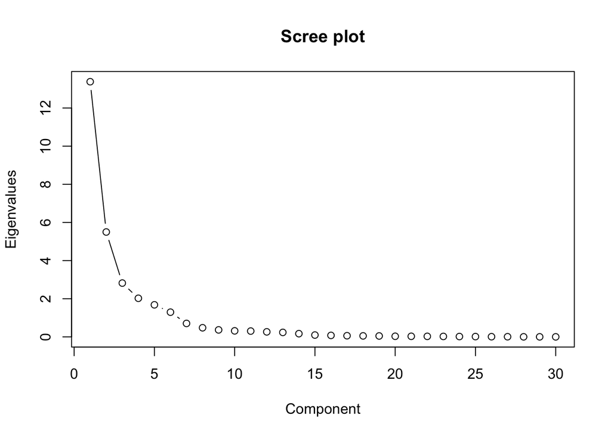

```r
## Extract the principal components
## Rotation can reduce (or eliminate) the correlation between the principal components
## and help explain the principal components.
pca <- principal(biopsy.zs.train[-1], nfactors = 8, rotate = "varimax")

## Find the point with small reduction rate.
## The point means that when a new principal component is added to this point,
## the explanation of variance does not increase too much.
plot(pca$values, type="b",main="Scree plot", ylab="Eigenvalues", xlab="Component")
```

```r
## Calcualte scores
pca.scores <- data.frame(pca$scores)
pca.scores$diagnosis <- biopsy.zs.train$diagnosis

## PCA Modeling using scores
LR.PCA.fit <- glm(diagnosis ~ ., family = binomial, data = pca.scores)

## Model Results
summary(LR.PCA.fit)
```

```
##
## Call:
## glm(formula = diagnosis ~ ., family = binomial, data = pca.scores)
##
## Deviance Residuals:
##     Min       1Q   Median       3Q      Max
## -1.9139  -0.0694  -0.0085   0.0006   3.5425
##
## Coefficients:
##             Estimate Std. Error z value Pr(>|z|)
## (Intercept) -0.74078    0.44394  -1.669 0.095189 .
## RC1         10.24876    1.86106   5.507 3.65e-08 ***
## RC2         -0.03948    0.59401  -0.066 0.947009
## RC5          3.25731    0.68408   4.762 1.92e-06 ***
## RC4          3.07373    0.60192   5.107 3.28e-07 ***
## RC6          1.37195    0.40526   3.385 0.000711 ***
## RC8          0.10365    0.41409   0.250 0.802349
## RC3          0.42950    0.39091   1.099 0.271891
## RC7          0.10360    0.51938   0.199 0.841895
## ---
## Signif. codes:  0 '***' 0.001 '**' 0.01 '*' 0.05 '.' 0.1 ' ' 1
##
## (Dispersion parameter for binomial family taken to be 1)
##
##     Null deviance: 524.741  on 404  degrees of freedom
## Residual deviance:  57.238  on 396  degrees of freedom
## AIC: 75.238
##
## Number of Fisher Scoring iterations: 9
```

```r
## Performance on the test dataset
test.scores <- data.frame(predict(pca, biopsy.zs.test[-1]))
LR.PCA.probs <- predict(LR.PCA.fit, test.scores,type = "response")

## Calculate the confusion matrix
InformationValue::confusionMatrix(testY, LR.PCA.probs)
```

|  | Benign | Malignant |
| --- | --- | --- |
| 0 | 94 | 7 |
| 1 | 0 | 63 |

**Finding:**

- PCA processes high-dimensional data (30 biomarkers) to low dimension data (PCA score), but inevitable loss is the interpretability of logistic regression.